# Comparing MCMC and VB in Stan

Ricard Argelaguet

European Bioinformatics Institute, Cambridge, UK

ricard@ebi.ac.uk

2019-11-15

# 1 Description

This vignette shows a comparison of the posterior estimates between the MCMC and ADVI (Automatic Differentiation Variational Inference) inference schemes implemented in Stan.

Code for the stan model was obtained from [here](https://www.cs.helsinki.fi/u/sakaya/tutorial/)

## 1.1 Load libraries and define general settings and functions

```r
library(data.table)
library(purrr)
library(ggplot2)
library(ggpubr)
library(rstan)
rstan_options(auto_write = TRUE)
```

```r
ntrials <- 25
```

```r
data_summary <- function(data){
  mean <- colMeans(data)
  sd <- apply(data, 2, sd)
  return(data.table("pred_mean" = mean, "pred_sd" = sd))
}

extract_summary_statistics <- function(fit, ntrials, params) {
  lapply(1:ntrials, function(i) {
    lapply(params, function(j) {
      data_summary(as.data.frame(extract(fit[[i]])[[j]])) %>%
      as.data.table %>%
      setnames(c("mean","sd")) %>%
      .[,parameter:=paste0(j,1:.N)] %>%
      .[,trial:=i]
    }) %>% rbindlist
  }) %>% rbindlist
}

do.scatterplot <- function(dt) {
  to.plot <- dt %>% dcast(parameter+trial+estimate ~ inference)
  lims <- c(min(dt$value), max(dt$value))

  p <- ggscatter(to.plot, x="ADVI", y="MCMC") +
    facet_wrap(~parameter) +
    geom_abline(slope=1, intercept=0, linetype="solid") +
    coord_cartesian(xlim = lims, ylim = lims)
  p
}
```

# 2 Beta binomial

This is the model:

$$\begin{align}
y &\sim \text{Bin}(N, \theta) \\
\theta &\sim \text{Beta}(\alpha, \beta)
\end{align}$$

with associated stan code:

```r
beta_binomial <- "
  data {
    int<lower=1> N;
    int<lower=1> s;
    int<lower=0> y[N];
  }
  parameters {
    real<lower=0, upper=1> theta;
  }
  model {
    theta ~ beta(1,1);
    for (i in 1:N)
      y[i] ~ binomial(s,theta);
  }
"
```

We have simulated multiple data sets from the generative model:

```r
N <- 100  # number of samples
s <- 10   # number of binomial trials

Y <- list()
for (i in 1:ntrials) {

  # Sample theta
  theta <- runif(1, min=0.1, max=0.9)

  # Sample binomial observations
  Y[[i]] <- rbinom(N, s, theta)
}
```

The fitting procedure is done as follows (takes a bit of time):

```r
st_model <- stan_model(model_code = beta_binomial, model_name="beta_binomial")

fit.mcmc <- list()
fit.vb <- list()
for (i in 1:ntrials) {
  print(sprintf("Fitting trial %d...",i))

  # Create data object for Stan
  data <- list(y=Y[[i]], N=N, s=s)

  # Perform inference using HMC sampling
  fit.mcmc[[i]] <- sampling(st_model,  data = data, chains = 1, iter=3000)

  # Perform inference using ADVI
  fit.vb[[i]] <- vb(st_model,  data = data, algorithm="meanfield", tol_rel_obj=0.001)
}
```

Extract summary statistics

```r
dt.mcmc <- extract_summary_statistics(fit.mcmc, ntrials=ntrials, params = "theta") %>%
  .[,inference:="MCMC"]
dt.vb <- extract_summary_statistics(fit.vb, ntrials=ntrials, params = "theta") %>%
  .[,inference:="ADVI"]

dt <- rbind(dt.vb, dt.mcmc) %>%
  melt(id.vars=c("parameter","inference","trial"), variable.name="estimate")
```

Compare means of the posterior distributions

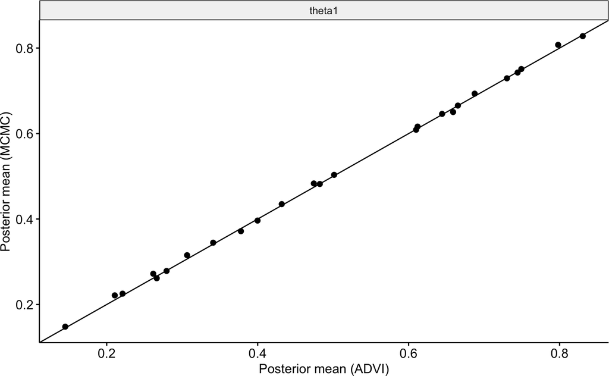

```r
do.scatterplot(dt[estimate=="mean"]) +
  labs(x="Posterior mean (ADVI)", y="Posterior mean (MCMC)")
```

Compare standard deviation of the posterior distributions

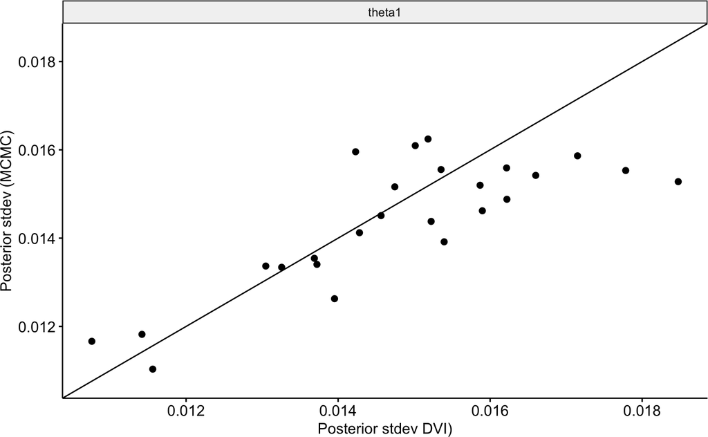

```r
do.scatterplot(dt[estimate=="sd"]) +
  labs(x="Posterior stdev DVI)", y="Posterior stdev (MCMC)")
```

# 3 Linear regression with ARD priors

This is the model:

$$\begin{align}
\alpha_{i=1\ldots K} &\sim \text{Gam}(\alpha_0, \beta_0)\\
\sigma^2 &\sim \text{InvGam}(\alpha_0, \beta_0) \\
\mathbf w &\sim \mathcal{N}(0, \boldsymbol \alpha^{-1} \mathbf I)\\
y &\sim \mathcal{N}(\mathbf w^{\top} \mathbf x, \sigma^2)\\
K &= \text{number of dimensions}
\end{align}$$

with associated Stan code:

```r
bayesian_linear_ard <- "
  data {
    int<lower=0> N;
    int<lower=0> D;
    matrix[N,D] X;
    vector[N] y;
  }

  parameters {
    vector[D] w;
    vector<lower=0>[D] alpha;
    real<lower=0> tau;
  }

  transformed parameters {
    vector<lower=0>[D] t_alpha;
    real<lower=0> t_tau;
    for (d in 1:D) t_alpha[d] = 1/sqrt(alpha[d]);
    t_tau =  1/sqrt(tau);
  }

  model {
    tau ~ gamma(1, 1);
    alpha ~ gamma(1e-3,1e-3);
    w ~ normal(0,  t_alpha);
    y ~ normal(X*w, t_tau);
  }
"
```

We have simulated multiple data sets from the generative model:

```r
N <- 1000  # Number of samples
D <- 10    # Number of features

Y <- list()
X <- list()
for (i in 1:ntrials) {

    # Sample tau
    tau <- runif(1, min=1, max=3)

    # Sample precision and inactivate some covariates elements
    alpha <- rep(0.1,D)
    alpha[sample(c(TRUE,FALSE),size=D, replace=TRUE)] <- 1e6

    # Sample weights (per feature)
    W <- sapply(1/sqrt(alpha), function(a) rnorm(1, mean=0, sd=a))

    # Sample covariates
    X[[i]] <- matrix(rnorm(N*D), N, D)

    # Sample observations and add noise to every sample
    Y[[i]] <- (X[[i]]%*%W)[,1] + rnorm(N, mean=0, sd = sqrt(1/tau))
}
```

The fitting procedure is done as follows (takes a bit of time):

```r
st_model <- stan_model(model_code = bayesian_linear_ard, model_name="bayesian_linear_ard")

fit.mcmc <- list()
fit.vb <- list()
for (i in 1:ntrials) {
  print(sprintf("Fitting trial %d...",i))

  # Create data object for Stan
  data <- list(N=N, D=D, X=X[[i]], y=Y[[i]])

  # Perform inference using HMC sampling
  fit.mcmc[[i]] <- sampling(st_model,  data = data, chains = 1, iter=3000)

  # Perform inference using ADVI
  fit.vb[[i]] <- vb(st_model,  data = data, algorithm="meanfield", tol_rel_obj=0.001)
}
```

Extract summary statistics

```r
dt.mcmc <- extract_summary_statistics(fit.mcmc, ntrials=ntrials, params = "w") %>%
  .[,inference:="MCMC"]
dt.vb <- extract_summary_statistics(fit.vb, ntrials=ntrials, params = "w") %>%
  .[,inference:="ADVI"]

dt <- rbind(dt.vb, dt.mcmc) %>%
  melt(id.vars=c("parameter","inference","trial"), variable.name="estimate")
```

Compare means of the posterior distributions

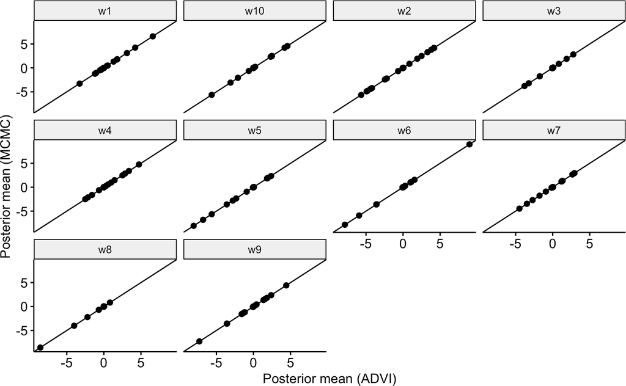

```r
do.scatterplot(dt[estimate=="mean"]) +
  labs(x="Posterior mean (ADVI)", y="Posterior mean (MCMC)")
```

Compare standard deviation of the posterior distributions

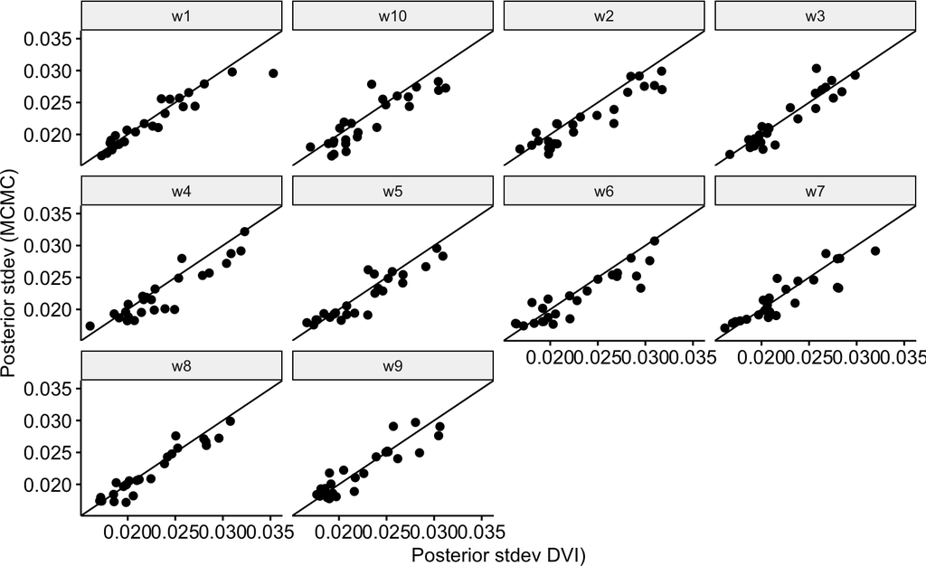

```r
do.scatterplot(dt[estimate=="sd"]) +
  labs(x="Posterior stdev DVI)", y="Posterior stdev (MCMC)")
```

# 4 Logistic regression with ARD priors

with associated stan code:

```r
bayesian_logistic_ard = "
  data {
    int<lower=1> N;      // number of samples
    int<lower=1> D;      // number of covariates
    int<lower=0,upper=1> y[N];            // binary outcome
    matrix[N, D] X;      // covariate matrix
  }

  parameters {
        vector[D] w;
        vector<lower=0>[D] alpha;
  }

    transformed parameters {
        vector<lower=0>[D] t_alpha;
        for (d in 1:D) t_alpha[d] = 1/sqrt(alpha[d]);
    }

  model {
        alpha ~ gamma(1e-3,1e-3);
        w ~ normal(0, t_alpha);
        y ~ bernoulli_logit(X*w);
  }
"
```

We have simulated multiple data sets from the generative model:

```r
# Specify dimensions
N <- 1000  # Number of samples
D <- 10    # Number of features

Y <- list()
X <- list()
for (i in 1:ntrials) {

  # Sample precision and inactivate some covariates elements
  alpha <- rep(0.1,D)
  alpha[sample(c(TRUE,FALSE),size=D, replace=TRUE)] <- 1e6

  # Sample weights (per feature)
  w <- sapply(1/sqrt(alpha), function(a) rnorm(1, mean=0, sd=a))

  # Sample covariates
  X[[i]] <- matrix(rnorm(N*D), N, D)

  # Sample observations and add noise to every sample
  Y[[i]] <- rbinom(N, 1, boot::inv.logit(c(X[[i]]%*%w + rnorm(N))))
}
```

The fitting procedure is done as follows (takes a bit of time):

```r
st_model <- stan_model(model_code = bayesian_logistic_ard, model_name="bayesian_logistic_ard")

fit.mcmc <- list()
fit.vb <- list()
for (i in 1:ntrials) {
  print(sprintf("Fitting trial %d...",i))

  # Create data object for Stan
  data <- list(N=N, D=D, X=X[[i]], y=Y[[i]])

  # Perform inference using HMC sampling
  fit.mcmc[[i]] <- sampling(st_model,  data = data, chains = 1, iter=3000)

  # Perform inference using ADVI
  fit.vb[[i]] <- vb(st_model,  data = data, algorithm="meanfield", tol_rel_obj=0.001)
}
```

Extract summary statistics

```r
dt.mcmc <- extract_summary_statistics(fit.mcmc, ntrials=ntrials, params = "w") %>%
  .[,inference:="MCMC"]
dt.vb <- extract_summary_statistics(fit.vb, ntrials=ntrials, params = "w") %>%
  .[,inference:="ADVI"]

dt <- rbind(dt.vb, dt.mcmc) %>%
  melt(id.vars=c("parameter","inference","trial"), variable.name="estimate")
```

Compare means of the posterior distributions

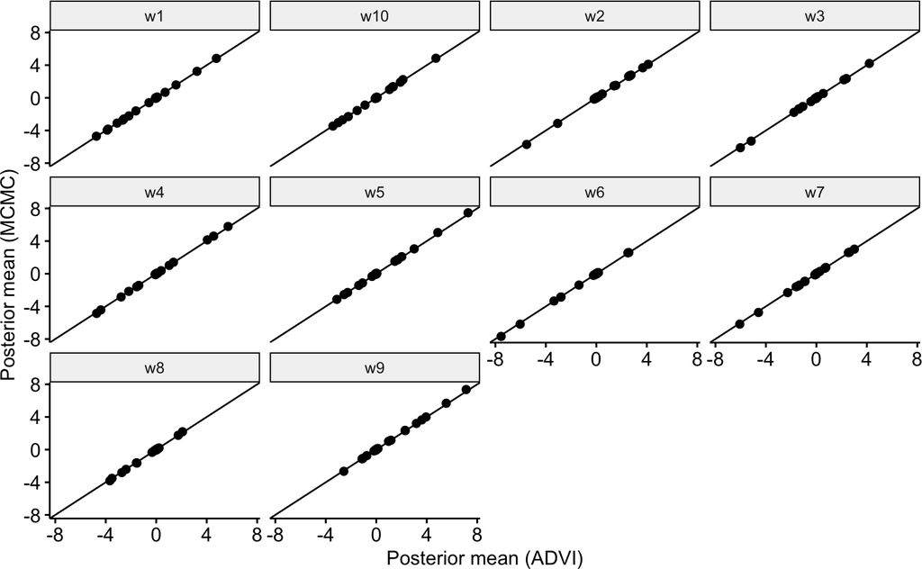

```r
do.scatterplot(dt[estimate=="mean"]) +
  labs(x="Posterior mean (ADVI)", y="Posterior mean (MCMC)")
```

Compare standard deviation of the posterior distributions

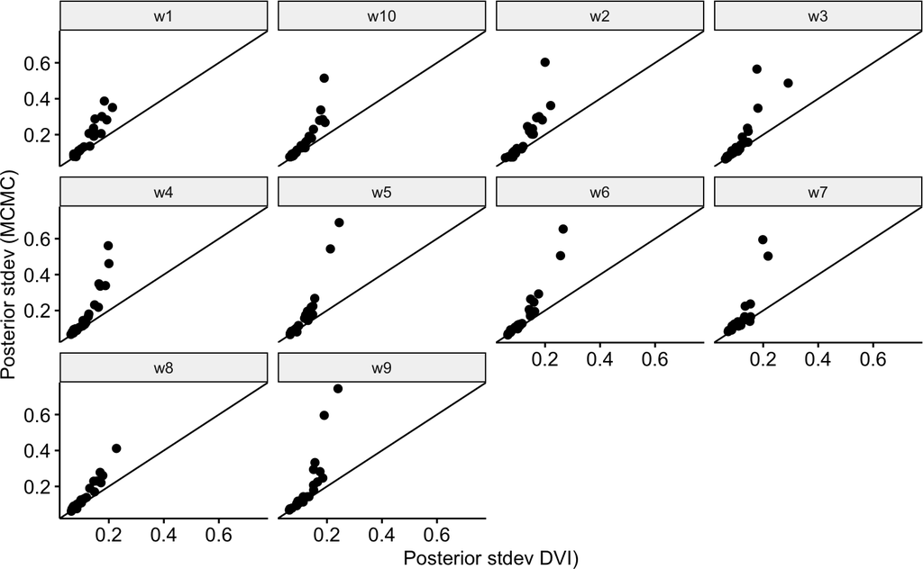

```r
do.scatterplot(dt[estimate=="sd"]) +
  labs(x="Posterior stdev DVI)", y="Posterior stdev (MCMC)")
```

# 5 Conclusion

As expected, the expectations are very well captured with variational inference. The variance estimates are ok for the linear models but a bit far off for the non-linear model, particularly for posterior distributions with higher uncertainity. This is consistent with the knowledge that VB tends to underestimate the true variance.